# How to Build Better Regression Models with Dimensional Analysis

(This python notebook was used to create an article to be reviewed and published at "TowardsDataScience")

**What We Will do in this Article**

1. Learn the basics of dimensional analysis.
2. Learn how to apply dimensional analysis to regression problems.
3. Develop a dimensionally sound, explainable regression model that produces an average $R^2$ of 0.93. The author of the book where this dataset was found produced an $R^2$ of 0.89 while predicting the log of the target we use.

**How to follow this article:** While this article does include code, the code isn't important nor is it complex. I'd recommend reading through first while ignoring the code, and then going back to understand the code if you wish.

```python
%matplotlib inline
import warnings
warnings.filterwarnings('ignore')
```

```python
import pandas as pd
import numpy as np
import matplotlib.pyplot as plt
import seaborn as sns
import scipy.stats as stats
import random
from patsy import dmatrices
from sklearn.linear_model import LinearRegression
from copy import deepcopy
from sklearn.model_selection import cross_validate
import models
from sklearn.metrics import mean_squared_error
from sklearn.metrics import mean_absolute_error
from sklearn.metrics import r2_score
from sklearn.model_selection import KFold
```

# Introduction

Often all we care about is building a model that can make good predictions. Sometimes, however, we care about explainability of model as well and many popular machine learning algorithms are not particularly explainable. When it comes to physical data (*kilograms, meters, coulombs, etc.*), we may also care about dimensional soundness. Fortunately, these dimensions have meanings; they aren't arbitrary. Because they have meanings, relationships between variables with such units must follow rules. We can leverage these rules to build a dimensionally sound and explainable model.

# Dimensional Analysis

The following approach is heavily dependent on an understanding of dimensional analysis. The general idea behind dimensional analysis is that if we are performing operations on quantities that have units, the operations are performed on the units themselves as well. We must then ensure dimensional equality as well as quantitative. For example, let's take a look at the formula for volumetric density of a cylinder.

$$ \rho= \dfrac{m}{\pi r^{2}h} $$

*For the following dimensional analysis, we'll assume generic units. Radius and height will be considered length units and called $L$. Mass will be given a generic label $M$. $\pi$ is a dimensionless constant.

From this we can gather the units of density ($\rho$) given the equation. To avoid confusion, I'll represent "has units" as $:$.

$$ \rho : \dfrac{M}{L*L*L}:M/L^{3} $$

We can also use this idea "check" relationships. For a given equation to be dimensionally sound, both sides of the equation must be consistent dimensionally.

*Note: When working with data that includes actual units, it makes sense to work with the same unit across all of such unit type (ex. use mm for all length units). This won't actually improve the models predictive ability, as unit conversions will be baked into fitting coefficients, but it will make things "cleaner".*

# Guessing Relationships

*Just a heads up: we don't actually use this process in the example with an actual dataset. Nonetheless, it is useful to know and in the same vein as the rest of the work here, so I figured I would add it.*

This idea can also help us guess relationships. If it's simple, we can usually guess the relationship quickly and confirm dimensional consistency. For more complex relationships, Rayleigh's method of dimensional analysis helps. I'll outline the idea using the data science terminology of "target" and "features".

Let $F_{1}, F_{2}, ... F_{n}$ be the set of $n$ predictive features. Let $T$ be the target. *The goal is to find:

$$ T = CF_{1}^{m_1}F_{2}^{m_2} \cdots F_{n}^{m_n} $$

Given that we know the dimensions of each feature, $F_i$, and the dimensions of the target, $T$, we can solve this relationship dimensionally by substituting in units and breaking the problem down into $l$ linear equations, where $l$ is determined to be the number of unique base units in $F_{1}, F_{2}, ... F_{n}$. I'll use volumetric density of a cylinder for an example.

*Note: We can also look at summing terms as well. As long as each individual term matches the dimensions on the left side of the equation. We will actually do this later in the main example.

## Example

I'm going to use the volumetric density of a cylinder as an example here. It's simple and we know the solution so keep in mind that for more difficult problems, more work and some linear algebra will be necessary.

The target is the density $\rho$ and the features are $m$, $r$, and $h$. We'll assume the same base units as before for each of these values. So now we have that:

$$ \rho = Cm^ar^bh^c $$

Using the base units of each, we can set up a single equation representing dimensional consistency. It's best to keep out fractions and instead use negative exponents to reduce errors for the next step. We can also ignore the constant, $C$, for the time being as we are assuming a dimensionless constant.

$$ M^1L^{-3}=M^aL^bL^c $$

We now break this down into several linear equations.

$$ 1 = a $$$$ -3 = b+c $$

The first equation is already solved for us and the second has an infinite number of solutions. This will not always be the case. Often there will be a single solution and other times no solution exists (which means you have to take a look at unit assumptions and ask yourself if such a relationships exists). For more complex relationships, linear algebra will expedite the process.

Enough about other possibilities though; let's continue to look at this specific equation. We know that an infinite number of solutions are possible so we guess and check likely solutions based on domain knowledge and experience. For this example, we understand that the equation represents the "volume" portion of density, and we know from experience that $V \sim Ah$ so we guess that $b=-2$ and $c=-1$.

Now we plug back in this solution to get:

$$ \rho = C \dfrac{m}{r^2 h} $$

So what's the deal with $C$? We know it should be $1/\pi$ but using this technique, we're only accurate to a constant. Remember that our use case is in the data science field, so we can run a regression to determine $C$. Essentially, all we've done thus far is extract the feature $\dfrac{m}{r^2 h}$ which we can run a linear regression on. Next, I'll go over a short example using real data that isn't quite as straight forward and do just this.

# Mesquite

The data set we'll use in the mesquite dataset. The dataset is used in "Data Analysis Using Regression and Multilevel/Hierarchical Models" by Gelman and Hill. The book resources can be found [here](http://www.stat.columbia.edu/~gelman/arm/). The particular chapter can be found [here](http://vulstats.ucsd.edu/pdf/Gelman.ch-04.regression-transformations.pdf). Our target will be `LeafWeight`. The book targets the log of `LeafWeight` instead which is a common technique when products of features predict the target. We'll approach the problem in a different manner which does not require taking the log.

## Basic Data Summary

```python
mesquite = pd.read_csv("./mesquite.tsv", sep='\s+', header=0)
mesquite_original = mesquite.copy()
```

```python
mesquite.info()
```

```
<class 'pandas.core.frame.DataFrame'>
RangeIndex: 46 entries, 0 to 45
Data columns (total 8 columns):
Obs       46 non-null int64
Group     46 non-null object
Diam1     46 non-null float64
Diam2     46 non-null float64
TotHt     46 non-null float64
CanHt     46 non-null float64
Dens      46 non-null int64
LeafWt    46 non-null float64
dtypes: float64(5), int64(2), object(1)
memory usage: 3.0+ KB
```

In order to leverage dimensionality, we need to understand the meaning behind each feature and their dimensions (this should always be done but is particularly important when using this method). In this section, I'll just enough EDA to answer the questions I have. Keep in mind that more EDA is generally necessary.

- Diam1: diameter of the canopy (the leafy area of the bush) in meters, measured along the longer axis of the bush
- Diam2: canopy diameter measured along the shorter axis
- canopy height: height of the canopy
- total height: total height of the bush
- density: plant unit density (# of primary stems per plant unit)
- group: group of measurements (0 for the first group, 1 for the second group)

Let's rename some of these columns so that they're easier to work with.

```python
mesquite = mesquite.rename(columns =
                           {
                               'Obs':'Observation',
                               'TotHt':'TotalHeight',
                               'CanHt':'CanopyHeight',
                               'Dens':'Density',
                               'LeafWt':'LeafWeight'
                           })
```

## Exploratory Data Analysis

### Total Height and Canopy Height

`CanopyHeight` will be represented as $h_c$ and `TotalHeight` will be represented as $h_T$ in equations. Both have $L$ (length) units.

The books provides the following definitions for these two features:

- canopy height: height of the canopy
- total height: total height of the bush

However, I'm still not sure I know the difference. Is the canopy height the height at which the canopy begins? Hopefully, a scatter plot will help make a determination. I'll add a red line to mark equality between the axis.

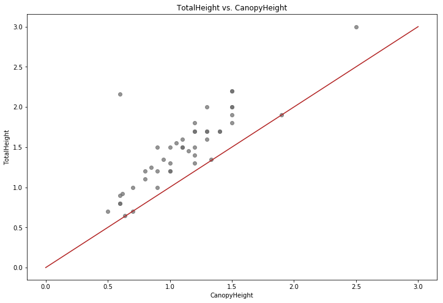

```python
figure = plt.figure(figsize=(12,8))

axes = figure.add_subplot(1, 1, 1)
axes.scatter(mesquite.CanopyHeight, mesquite.TotalHeight, color='dimgray', alpha=0.7)
axes.set_xlabel('CanopyHeight')
axes.set_ylabel('TotalHeight')
axes.set_title('TotalHeight vs. CanopyHeight')

equal = np.linspace(0, max(max(mesquite.CanopyHeight), max(mesquite.TotalHeight)), 100)
axes.plot(equal, equal, '-', color='firebrick')
```

The red line above represents the line $y=x$. Since all the data points are above this line, we can conclude that `TotalHeight` is greater than or equal to `CanopyHeight`, which we already knew. At this point, we have two hypotheses about what `CanopyHeight` represents:

- The distance from the ground to the bottom of the canopy
- The distance from the bottom of the canopy to the top of the canopy

We know that the distance from the bottom of the canopy to the top of the canopy should be positive. So assuming the first interpretation of `CanopyHeight`, we know the `TotalHeight`-`CanopyHeight` must be positive. Let's check that.

```python
total = sum((mesquite.TotalHeight-mesquite.CanopyHeight)>0)/mesquite.shape[0]
print("{0:.2f} of observations have a TotalHeight > CanopyHeight".format(total))
```

```
0.96 of observations have a TotalHeight > CanopyHeight
```

Because some observations do not fit the stated requirement, we can conclude that the second interpretation is true.

### Density

The notes found provide the following definition:

- density: plant unit density (# of primary stems per plant unit)

Still, that's not exactly clear; domain specific knowledge may be necessary to interpret this definition. Is a single observation considered a single unit? What's a primary stem? A quick google search did not provide any additional information. Let's take a look at the counts to see if we can gather a better understanding.

```python
mesquite['Density'].value_counts().sort_index()
```

```
1    33
2     7
3     3
5     1
7     1
9     1
Name: Density, dtype: int64
```

`Density` is a strictly positive integer feature with a majority of bushes having a `Density` of 1. While looking at pictures of mesquite bushes, I noticed that many bushes only have one stem from the ground with some having a few additional stems. Therefore, we'll conclude that `Density` is the number of stems originating from the ground. `Density` must then have units of 'number of stems' $N$, and will be represented by $p$. For practical purposes, we can treat this as a dimensionless constant. You can think of it as a multiplier that has no generic base unit. In terms of influencing the total leaf weight, however, I'm unsure it will provide significant information. We may have to be creative with how we add this feature.

## Building the Model

When building this model, we'll ignore `Group` for the time being. Based on the description, there isn't a clear logical reason it will significantly help and it certainly won't help when building our dimensionally sound model. It will only distract.

Because the influence of `Density` on the target is not obvious, we'll compare the evaluation results without it included to the evaluation results with it included.

### First Theoretical Model

Let's quickly define some more equation variables. The target, `LeafWeight`, has base units of mass $M$, and will be represented as $W_L$ in equations. The two diameters will be represented as $d_1$ and $d_2$. The goal now is to find a dimensionally sound relationship as follows:

$$ W_L = F(d_1, d_2, h_T, h_c, p) $$

The idea is to find some combination of features that represents a volume encompassing a density of leaves. The coefficient extracted in the regression will include the volumetric density of the leaves in that volume.

We start with the knowledge that $V \sim Ah$. We will represent the area as the area of an ellipse, $A_{ellipse} \sim d_1d_2$. We could also add a dimensionless feature, `shape`, ($s = d_1/d_2$), to represent the asymmetry of the bush. We'll add this in later models. In this attempt, we're also including $p$, which may or may not help. So now we have the model.

$$ W_L = \alpha_0 + \alpha_1 p d_1d_2 h_c $$

$\alpha_0$ must have $M$ units and $\alpha_1$ must have $M/L^{3}$ units for dimensional consistency. This fits our previous description of thinking of $a_1$ as a leaf density in a volume.

This is now our starting model for regression. We'll engineer a new a feature for $p d_1d_2 h_c$ and run a regression with that feature as the only predictive feature.

### First Regression

```python
np.random.seed(453245)
```

```python
mesquite['model_1'] = mesquite['Density']*mesquite['Diam1']*mesquite['Diam2']*mesquite['CanopyHeight']
```

```python
def bootstrap_regression(data, formula, estimator, samples=100):

    bootstrap_results = {}

    sigmas = []
    r2s = []
    maes = []

    n = data.shape[ 0]
    bootstrap_results[ "n"] = n


    for i in range(samples):


        sampling_indices = pd.Index([i for i in [np.random.randint(0, n - 1) for _ in range(0, n)]])
        sample = data.loc[sampling_indices]
        y_sample, X_sample = dmatrices(formula, sample)

        estimator.fit(X_sample, y_sample)
        y_predict = estimator.predict(X_sample)

        sigma = np.sqrt(mean_squared_error(y_sample, y_predict))
        r2 = r2_score(y_sample, y_predict)
        mae = mean_absolute_error(y_sample, y_predict)

        sigmas.append(sigma)
        r2s.append(r2)
        maes.append(mae)

    # Get a set of residuals
    y, X = dmatrices(formula, data)
    estimator.fit(X, y)
    y_predict = estimator.predict(X)
    bootstrap_results["residuals"] = y-y_predict

    bootstrap_results["resampled_mae"] = pd.Series(maes)
    bootstrap_results["resampled_sigma"] = pd.Series(sigmas)
    bootstrap_results["resampled_r^2"] = pd.Series(r2s)


    # Find credible intervals
    mae_cred = np.array2string(stats.mstats.mquantiles(maes, [0.25, .975]), precision=3, separator=',')
    sigma_cred = np.array2string(stats.mstats.mquantiles(sigmas, [0.25, .975]), precision=3, separator=',')
    r2_cred = np.array2string(stats.mstats.mquantiles(r2s, [0.25, .975]), precision=3, separator=',')


    # Print results
    print("MAE Resample Mean: {0:.3f}".format(np.mean(maes)))
    print("95% Credible Interval for MAE: ", mae_cred)
    print("Sigma Resample Mean: {0:.3f}".format(np.mean(sigmas)))
    print("95% Credible Interval for sigma: ", sigma_cred)
    print("R2 Resample Mean: {0:.3f}".format(np.mean(r2s)))
    print("95% Credible Interval for R2: ", r2_cred)


    return bootstrap_results
```

```python
formula = 'LeafWeight ~ model_1'
score_1 = bootstrap_regression(mesquite, formula, LinearRegression(), samples = 500)
```

```
MAE Resample Mean: 229.580
95% Credible Interval for MAE:  [207.448,299.46 ]
Sigma Resample Mean: 288.533
95% Credible Interval for sigma:  [262.388,361.327]
R2 Resample Mean: 0.676
95% Credible Interval for R2:  [0.529,0.924]
```

```python
mesquite['model_2'] = mesquite['Diam1']*mesquite['Diam2']*mesquite['CanopyHeight']
```

```python
formula = 'LeafWeight ~ model_2'
score_2 = bootstrap_regression(mesquite, formula, LinearRegression(), samples = 500)
```

```
MAE Resample Mean: 143.915
95% Credible Interval for MAE:  [129.532,183.581]
Sigma Resample Mean: 191.788
95% Credible Interval for sigma:  [170.946,248.343]
R2 Resample Mean: 0.845
95% Credible Interval for R2:  [0.753,0.972]
```

At first glance, this is a significant improvement. Fortunately, we can measure how *significant* since we have a *distribution* of scores for both models. Below, we'll determine the probability that the model excluding density performs better than the model including density based on the bootstrap samples. We'll refer to the model including `Density` as model_1 and the model excluding `Density` as model_2.

```python
difference = {}
difference['mae'] = score_2['resampled_mae'] - score_1['resampled_mae']
difference['sigma'] = score_2['resampled_sigma'] - score_1['resampled_sigma']
difference['R2'] = score_2['resampled_r^2'] - score_1['resampled_r^2']

print("P(model_2 mae < model_1 mae) = {0:.2f}".format(np.mean(difference['mae']<0)))
print("P(model_2 sigma < model_1 sigma) = {0:.2f}".format(np.mean(difference['sigma']<0)))
print("P(model_2 R2 > model_1 R2) = {0:.2f}".format(np.mean(difference['R2']>0)))
```

```
P(model_2 mae < model_1 mae) = 0.98
P(model_2 sigma < model_1 sigma) = 0.97
P(model_2 R2 > model_1 R2) = 0.77
```

Based on these numbers, it is very likely that excluding `Density` from our engineered predictive feature produces a better model. Well, this statement isn't entirely true. The difference between the features is actually $p^0 d_1 d_2 h_c$ vs. $p^1 d_1 d_2 h_c$. Recall that in our model, we can treat $p$ as dimensionless. Therefore, we can raise it to any power and stay dimensionally consistent. So far we have only tested two valid powers. We can treat this power as a model parameter and utilize a validation plot to find the optimal power. Since this isn't a typical parameter, we'll have to use a custom validation plot function. The function below could easily be generalized with a few edits if you choose to do so.

```python
np.random.seed(532152)
```

```python
def power_validation_plot(data, features_to_mult, feature_to_optimize, powers, fit_intercept=True,
                          repetitions=20, folds=5):

    scores = {}
    scores['p'] = []
    scores['train'] = []
    scores['train_std'] = []
    scores['test'] = []
    scores['test_std'] = []

    # create template feature that is product of all input features other than the one to optimize
    features_to_mult.remove(feature_to_optimize)
    template_feature = None
    for feature in features_to_mult:
        if template_feature is None:
            template_feature = data[feature]
        else:
            template_feature = template_feature*data[feature]

    for p in powers:

        # create test feature
        test_feature = template_feature*data[feature_to_optimize]**p
        param_score_train = []
        param_score_test = []

        for _ in range(repetitions):

            # Perform cross validation and get scores
            kf = KFold(folds, shuffle=True)
            for train_index, test_index in kf.split(test_feature):

                test_feature_train = pd.DataFrame(test_feature.iloc[train_index])
                test_feature_test = pd.DataFrame(test_feature.iloc[test_index])
                y_train = pd.DataFrame(data.loc[train_index, 'LeafWeight'])
                y_test = pd.DataFrame(data.loc[test_index, 'LeafWeight'])

                # Fit model
                lr = LinearRegression(fit_intercept=fit_intercept)
                lr.fit(test_feature_train, y_train)

                # Get scores and add to param_score list
                train_score = lr.score(test_feature_train, y_train)
                test_score = lr.score(test_feature_test, y_test)
                param_score_train.append(train_score)
                param_score_test.append(test_score)

        # Append param_scores to 'master' score
        scores['p'].append(p)
        scores['train'].append(np.mean(param_score_train))
        scores['train_std'].append(np.std(param_score_train))
        scores['test'].append(np.mean(param_score_test))
        scores['test_std'].append(np.std(param_score_test))

    scores = pd.DataFrame(scores)

    # Getting bounds of confidence interval
    train_upper = scores['train'] + scores['train_std']
    train_lower = scores['train'] - scores['train_std']
    test_upper = scores['test'] + scores['test_std']
    test_lower = scores['test'] - scores['test_std']

    # Create plot
    figure = plt.figure(figsize=(12,8))
    axes = figure.add_subplot(1, 1, 1)
    axes.plot(scores["p"], scores["train"], '-', label='train', color ='firebrick')
    axes.plot(scores["p"], scores["test"], '-', label='test', color = 'steelblue')
    axes.fill_between(scores["p"], train_upper, train_lower, color='firebrick', alpha=0.25)
    axes.fill_between(scores["p"], test_upper, test_lower, color='steelblue', alpha=0.25)
    axes.legend()
    axes.set_xlabel('Power')
    axes.set_ylabel(r'$R^2$')
    axes.set_title("Validation Curve for Power of " + feature_to_optimize)
    axes.set_xticks(powers)
    axes.set_ylim([0.0, 1.0])

    plt.show()
    plt.close()

    return scores
```

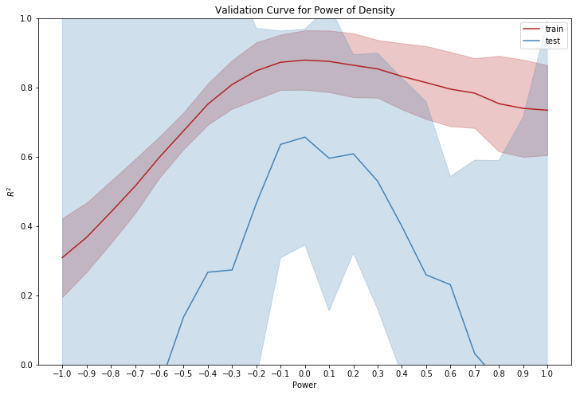

```python
powers = np.linspace(start=-1.0, stop=1.0, num=21)
features_to_mult = ['Density', 'Diam1', 'Diam2', 'CanopyHeight']
feature_to_optimize = 'Density'
validation_scores = power_validation_plot(mesquite, features_to_mult, feature_to_optimize, powers)
```

Both the test curve and the training curve appear to peak around 0 so we can conclude that it is best to leave to the `Density` ($p$) from the extracted feature which brings us to the following model:

$$ W_L = \alpha_0 + \alpha_1 d_1 d_2 h_c $$

### Considering the Intercept

At it's current state our model is:

$$ W_L = \alpha_0 + \alpha_1 d_1 d_2 h_c $$

Remember that the goal here is to build a dimensionally sound explainable model. So what do we know about this coefficient $\alpha_0$? We know that it must have $M$ units and we know that it represents `LeafWeight` ($W_L$) when the either measured diameter of the canopy, or the height of the canopy is $0$. In other words, it's the `LeafWeight` ($W_L$) without a canopy. Therefore, physically speaking, $\alpha_0$ should be $0$ and removed as a regression coefficient.

Let's see how our model performs when removing $\alpha_0$. The model we are now looking at follows:

$$ W_L = \alpha_1 d_1 d_2 h_c $$

```python
np.random.seed(4235291)
```

```python
formula = 'LeafWeight ~ model_2'
score_3 = bootstrap_regression(mesquite, formula, LinearRegression(fit_intercept=False), samples = 500)
```

```
MAE Resample Mean: 144.032
95% Credible Interval for MAE:  [128.938,190.931]
Sigma Resample Mean: 191.426
95% Credible Interval for sigma:  [172.039,250.331]
R2 Resample Mean: 0.843
95% Credible Interval for R2:  [0.769,0.972]
```

These credible intervals almost completely overlap those from when the intercept was included. Therefore, we can probably remove the intercept from the mode. Let's repeat the previous validation curve to confirm with a test set (this will also confirm that a power of 0 is appropriate still if we remove the intercept).

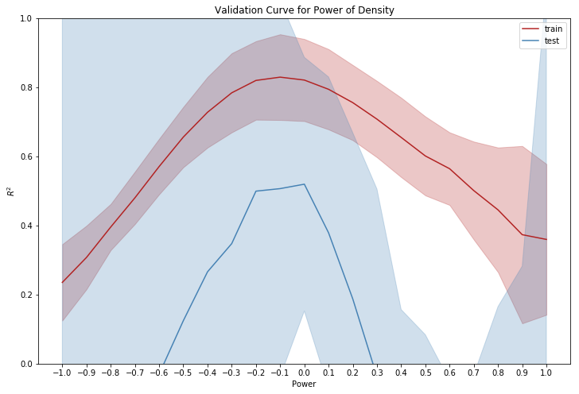

```python
powers = np.linspace(start=-1.0, stop=1.0, num=21)
features_to_mult = ['Density', 'Diam1', 'Diam2', 'CanopyHeight']
feature_to_optimize = 'Density'
validation_scores = power_validation_plot(mesquite, features_to_mult, feature_to_optimize, powers, fit_intercept=False)
```

We can see a clear drop-off in $R^2$ when we remove the intercept from the model. This may just be due to the small size of the dataset, but we'll keep the intercept for now.

### Adding Shape Asymmetry to the Model

In our theoretical analysis thus far, we have only considered "perfect" shapes. However, imperfections, such as a disparity between `Diam1` and `Diam2` may influence `LeafWeight` as well. We are going to include this by inserting $d_1/d_2$ somewhere in our previous model. Because this is a dimensionless value, we have a lot of options. As a start we'll look at:

$$ W_L = \alpha_0 + \alpha_1(d_1/d_2)^m d_1 d_2 h_c $$

and optimize $m$.

```python
np.random.seed(3213193)
```

```python
mesquite['shape_1'] = mesquite['Diam1']/mesquite['Diam2']
```

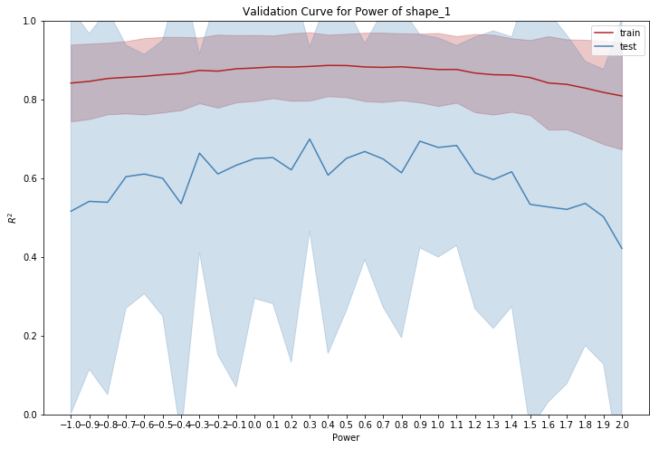

```python
powers = np.linspace(start=-1.0, stop=2.0, num=31)
features_to_mult = ['shape_1', 'Diam1', 'Diam2', 'CanopyHeight']
feature_to_optimize = 'shape_1'
validation_scores = power_validation_plot(mesquite, features_to_mult, feature_to_optimize, powers)
```

It appears that some gains can be made using by adding this shape detail with a power of $1/2$. However, realistically, these may be negligible. We'd need more data to know for sure.

Remember that this isn't the only way to consider for shape. There is an infinite number of possibilities, this is just one of them. Let's try it a different way:

$$ W_L = \alpha_0 + \alpha_1(1+d_1/d_2)^m d_1 d_2 h_c $$

We'll search for the optimal $m$.

```python
mesquite['shape_2'] = 1+mesquite['Diam1']/mesquite['Diam2']
```

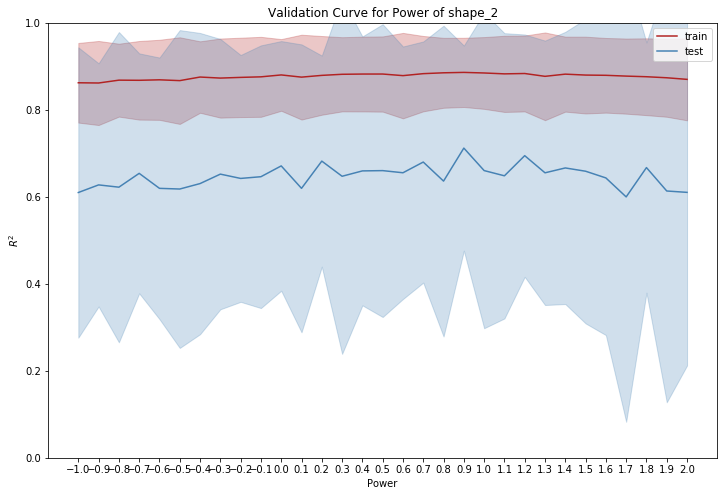

```python
powers = np.linspace(start=-1.0, stop=2.0, num=31)
features_to_mult = ['shape_2', 'Diam1', 'Diam2', 'CanopyHeight']
feature_to_optimize = 'shape_2'
validation_scores = power_validation_plot(mesquite, features_to_mult, feature_to_optimize, powers)
```

Again, it appears that some gains can be made here; however, again the gains may be negligible. We could try different models for adding shape but for the time being, we'll continue with the following based on the insights from the validation plots:

$$ W_L = \alpha_0 + \alpha_1(d_1/d_2)^{1/2} d_1 d_2 h_c $$

```python
mesquite['CanopyHeight_Term'] = (mesquite['Diam1']/mesquite['Diam2'])**(1/2)*mesquite['Diam1']*mesquite['Diam2']*mesquite['CanopyHeight']
```

Let's now develop our credible intervals for this model as our new baseline.

```python
formula = 'LeafWeight ~ CanopyHeight_Term'
score_4 = bootstrap_regression(mesquite, formula, LinearRegression(), samples = 500)
```

```
MAE Resample Mean: 137.272
95% Credible Interval for MAE:  [123.928,179.249]
Sigma Resample Mean: 185.288
95% Credible Interval for sigma:  [164.237,242.635]
R2 Resample Mean: 0.848
95% Credible Interval for R2:  [0.779,0.975]
```

### Adding Total Height to Model

So far, we have only considered the `CanopyHeight` in the model. It's still possible `TotalHeight` contributes to `LeafWeight` as well. Again, we have a lot of options; we just need to stay dimensionally consistent. We'll try adding it in the same way as `CanopyHeight`:

$$ W_L = \alpha_0 + \alpha_1(d_1/d_2)^{1/2} d_1 d_2 h_c + \alpha_2 d_1 d_2 h_T $$

Again, there are many options to explore, this is just one of them.

```python
np.random.seed(412310)
```

```python
mesquite['TotalHeight_Term'] = mesquite['Diam1']*mesquite['Diam2']*mesquite['TotalHeight']
```

```python
formula = 'LeafWeight ~ CanopyHeight_Term + TotalHeight_Term'
score_5 = bootstrap_regression(mesquite, formula, LinearRegression(), samples = 500)
```

```
MAE Resample Mean: 121.831
95% Credible Interval for MAE:  [110.548,153.799]
Sigma Resample Mean: 155.733
95% Credible Interval for sigma:  [140.669,196.775]
R2 Resample Mean: 0.903
95% Credible Interval for R2:  [0.869,0.982]
```

This appears to be a significant improvement. As stated before, we could try to augment this new term to see if more improvements can be found, but for sake of brevity, we'll leave it as is.

Let's confirm that improvements were made.

```python
difference = {}
difference['mae'] = score_5['resampled_mae'] - score_4['resampled_mae']
difference['sigma'] = score_5['resampled_sigma'] - score_4['resampled_sigma']
difference['R2'] = score_5['resampled_r^2'] - score_4['resampled_r^2']

print("P(new mae < current mae) = {0:.2f}".format(np.mean(difference['mae']<0)))
print("P(new sigma < current sigma) = {0:.2f}".format(np.mean(difference['sigma']<0)))
print("P(new R2 > current R2) = {0:.2f}".format(np.mean(difference['R2']>0)))
```

```
P(new mae < current mae) = 0.72
P(new sigma < current sigma) = 0.78
P(new R2 > current R2) = 0.64
```

So there is a 0.72 probability that we improved our mean-absolute-error score, a 0.78 probability that we improved our root-mean-squared-error score, and a 0.64 probability we improved our $R^2$ score. So it's likely we improved our model. Our model is now:

$$ W_L = \alpha_0 + \alpha_1(d_1/d_2)^{1/2} d_1 d_2 h_c + \alpha_2 d_1 d_2 h_T $$

### Adding Group

There are certainly more dimensional terms to explore. However, we could in theory endlessly explore options. Therefore, let's leave the dimensional features alone and add in `Group`. Normally, we would go through some EDA first, but this is not an EDA guide. We'll simply one-hot-encode the variable and add it in as an interacting feature. The model we are now exploring is:

$$ W_L = \alpha_0 + (\alpha_1 + \beta_1)(d_1/d_2)^{1/2} d_1 d_2 h_c + (\alpha_2 + \beta_2) d_1 d_2 h_T $$

The betas are non-zero (value determined by regression) when `Group=MCD` and 0 otherwise. They represent interaction.

```python
np.random.seed(5351523)
```

```python
# One hot encoding
mesquite['MCD'] = mesquite.Group == 'MCD'
```

```python
formula = 'LeafWeight ~ CanopyHeight_Term:MCD + TotalHeight_Term:MCD'
score_6 = bootstrap_regression(mesquite, formula, LinearRegression(), samples = 500)
```

```
MAE Resample Mean: 98.372
95% Credible Interval for MAE:  [ 87.01 ,129.802]
Sigma Resample Mean: 127.832
95% Credible Interval for sigma:  [115.746,160.091]
R2 Resample Mean: 0.932
95% Credible Interval for R2:  [0.906,0.988]
```

This certainly appears to be an improvement. Let's confirm that it is.

```python
difference = {}
difference['mae'] = score_6['resampled_mae'] - score_5['resampled_mae']
difference['sigma'] = score_6['resampled_sigma'] - score_5['resampled_sigma']
difference['R2'] = score_6['resampled_r^2'] - score_5['resampled_r^2']

print("P(new mae < current mae) = {0:.2f}".format(np.mean(difference['mae']<0)))
print("P(new sigma < current sigma) = {0:.2f}".format(np.mean(difference['sigma']<0)))
print("P(new R2 > current R2) = {0:.2f}".format(np.mean(difference['R2']>0)))
```

```
P(new mae < current mae) = 0.82
P(new sigma < current sigma) = 0.84
P(new R2 > current R2) = 0.60
```

Again, it appears that we have improved our model further. While it's possible we could make further improvements, this will be our final model:

$$ W_L = \alpha_0 + (\alpha_1 + \beta_1)(d_1/d_2)^{1/2} d_1 d_2 h_c + (\alpha_2 + \beta_2) d_1 d_2 h_T $$

The coefficients are determined by running the regression.

As a side note, we haven't applied cross-validation very much in this project. Normally, we would but this data set is very small ($n=46$) so our test sets would be incredibly small. Looking at the validation curves we did plot, we can see how this can be a problem. The blue area, representing plus or minus one standard deviation, is huge. Also, the goal of the project was to show how to build dimensionally sound, explainable regression models; repeating cross-validations at each step would distract from the goal.

## Summary

When working with data that includes units with meaning, consider leveraging dimensional analysis. Through dimensional analysis and slowly building a regression model, we can develop a dimensionally sound, highly explainable model. For the mesquite example, we were able to produce a dimensionally sound, explainable model with a mean $R^2$ of 0.93, improving upon scores produced by other approaches on the same dataset.

**Citations:**

Gelman, Andrew, and Jennifer Hill. 2007. Data Analysis Using Regression and Multilevel/Hierarchical Models. Analytical Methods for Social Research. Cambridge: Cambridge University Press.